# 2011년 압구정역

# 2011년 압구정역 월별 시간별 승하차 인원 비율 분석

### 월별 승하차 인원 통합 비율 분석

### 월별 시간별 승차 비율 분석

##### 패키지로딩

```r
library(tidyr)
library(dplyr)
```

```r
library(ggplot2)
library(lubridate)
library(reshape2)
Subwaydata <- read.csv("서울교통공사_1~8호선일별역별시간대별승하차인원_2011년.csv")
View(Subwaydata)
```

#### 해당 데이터를 로딩한다.

```r
table(is.na(Subwaydata))
```

```
##
##   FALSE
## 4660320
```

#### 데이터가 결측치가 있는지 확인한다.

#### 결측치가 없는 것을 확인 했다.

```r
subwaydata <- Subwaydata
```

##### 백업 파일을 하나 만든다.

```r
subwaydata$X05.06 <- as.numeric(subwaydata$X05.06)
subwaydata$X06.07 <- as.numeric(subwaydata$X06.07)
subwaydata$X07.08 <- as.numeric(subwaydata$X07.08)
subwaydata$X08.09 <- as.numeric(subwaydata$X08.09)
subwaydata$X09.10 <- as.numeric(subwaydata$X09.10)
subwaydata$X10.11 <- as.numeric(subwaydata$X10.11)
subwaydata$X11.12 <- as.numeric(subwaydata$X11.12)
subwaydata$X12.13 <- as.numeric(subwaydata$X12.13)
subwaydata$X13.14 <- as.numeric(subwaydata$X13.14)
subwaydata$X14.15 <- as.numeric(subwaydata$X14.15)
subwaydata$X15.16 <- as.numeric(subwaydata$X15.16)
subwaydata$X16.17 <- as.numeric(subwaydata$X16.17)
subwaydata$X17.18 <- as.numeric(subwaydata$X17.18)
subwaydata$X18.19 <- as.numeric(subwaydata$X18.19)
subwaydata$X19.20 <- as.numeric(subwaydata$X19.20)
subwaydata$X20.21 <- as.numeric(subwaydata$X20.21)
subwaydata$X21.22 <- as.numeric(subwaydata$X21.22)
subwaydata$X22.23 <- as.numeric(subwaydata$X22.23)
subwaydata$X23.24 <- as.numeric(subwaydata$X23.24)
subwaydata$X24. <- as.numeric(subwaydata$X24.)
subwaydata$날짜 <- as.Date(subwaydata$날짜)
```

#### 데이터를 처리하기 위해 알맞는 데이터형으로 형 변환 처리 해준다.

```r
str(subwaydata)
```

```
## 'data.frame':    194180 obs. of  24 variables:
##  $ 날짜  : Date, format: "2011-01-01" "2011-01-01" ...
##  $ 역번호: int  150 150 151 151 152 152 153 153 154 154 ...
##  $ 역명  : Factor w/ 266 levels "가락시장(340)",..: 131 131 147 147 224 224 225 225 228 228 ...
##  $ 구분  : Factor w/ 2 levels "승차","하차": 1 2 1 2 1 2 1 2 1 2 ...
##  $ X05.06: num  1249 1014 1751 1146 1774 ...
##  $ X06.07: num  2586 357 3025 1077 2808 ...
##  $ X07.08: num  5774 584 8039 2564 2584 ...
##  $ X08.09: num  56 788 3579 6481 6450 ...
##  $ X09.10: num  773 2351 3024 4153 4086 ...
##  $ X10.11: num  1472 1543 1107 4042 3751 ...
##  $ X11.12: num  2377 1534 2193 4214 4068 ...
##  $ X12.13: num  2743 1912 3866 4728 4670 ...
##  $ X13.14: num  2613 1796 4059 5340 59 ...
##  $ X14.15: num  2343 1732 4896 5299 252 ...
##  $ X15.16: num  3112 1922 5564 5554 630 ...
##  $ X16.17: num  2925 1691 5882 5667 1237 ...
##  $ X17.18: num  3078 1760 92 5816 1664 ...
##  $ X18.19: num  4334 976 156 5801 2926 ...
##  $ X19.20: num  3062 877 8172 3830 1704 ...
##  $ X20.21: num  2396 597 6213 2146 1354 ...
##  $ X21.22: num  2096 371 6171 2304 1915 ...
##  $ X22.23: num  1914 503 4476 1249 1741 ...
##  $ X23.24: num  51 3637 1079 3795 278 ...
##  $ X24.  : num  1180 958 1391 1268 1028 ...
```

#### str함수를 이용해서 각 데이터형이 알맞게 변했는지 확인한다.

```r
names(subwaydata) <- c('날짜', '역번호','역명','구분', 'h05.06', 'h06.07', 'h07.08', 'h08.09','h09.10','h10.11','h11.12','h12.13','h13.14','h14.15','h15.16','h16.17','h17.18','h18.19','h19.20','h20.21','h21.22','h22.23','h23.24','h24.')
```

#### 데이터의 변수 이름을 알기 쉽게 변환해준다.

```r
head(subwaydata)
```

```
##         날짜 역번호        역명 구분 h05.06 h06.07 h07.08 h08.09 h09.10 h10.11
## 1 2011-01-01    150 서울역(150) 승차   1249   2586   5774     56    773   1472
## 2 2011-01-01    150 서울역(150) 하차   1014    357    584    788   2351   1543
## 3 2011-01-01    151   시청(151) 승차   1751   3025   8039   3579   3024   1107
## 4 2011-01-01    151   시청(151) 하차   1146   1077   2564   6481   4153   4042
## 5 2011-01-01    152   종각(152) 승차   1774   2808   2584   6450   4086   3751
## 6 2011-01-01    152   종각(152) 하차   1384   1935   2544   8699   7908   4590
##   h11.12 h12.13 h13.14 h14.15 h15.16 h16.17 h17.18 h18.19 h19.20 h20.21 h21.22
## 1   2377   2743   2613   2343   3112   2925   3078   4334   3062   2396   2096
## 2   1534   1912   1796   1732   1922   1691   1760    976    877    597    371
## 3   2193   3866   4059   4896   5564   5882     92    156   8172   6213   6171
## 4   4214   4728   5340   5299   5554   5667   5816   5801   3830   2146   2304
## 5   4068   4670     59    252    630   1237   1664   2926   1704   1354   1915
## 6    157    410    838    892    966   1183   1489   2843    381   6221   5211
##   h22.23 h23.24 h24.
## 1   1914     51 1180
## 2    503   3637  958
## 3   4476   1079 1391
## 4   1249   3795 1268
## 5   1741    278 1028
## 6   3472   2085 1191
```

#### 변수명이 알맞게 변경되있는지 확인 및 데이터 값을 확인한다.

```r
subwaydata$날짜 = substr(subwaydata$날짜, 1, 7)
```

#### substr를 이용해서 ‘0000-00’ 형식이 되게끔 잘라준다.

```r
subwaydata_new <- subwaydata %>% filter(역명 == "압구정(326)")
```

#### filter를 이용해서 역명이 ’압구정역’인 데이터를 출력한다. subwaydate_new 에 데이터 저장

```r
head(subwaydata_new)
```

```
##      날짜 역번호        역명 구분 h05.06 h06.07 h07.08 h08.09 h09.10 h10.11
## 1 2011-01    326 압구정(326) 승차    831   2013   1479   6491   4064   3815
## 2 2011-01    326 압구정(326) 하차    933   2361   3702   9747   8025   4652
## 3 2011-01    326 압구정(326) 승차    752   1912   1441   7533   5120   4352
## 4 2011-01    326 압구정(326) 하차    955   2424   4740    128   2199    780
## 5 2011-01    326 압구정(326) 승차    786   2395   7862    511     37    205
## 6 2011-01    326 압구정(326) 하차   1762    234   2817  11408   7780   2928
##   h11.12 h12.13 h13.14 h14.15 h15.16 h16.17 h17.18 h18.19 h19.20 h20.21 h21.22
## 1   4105   4723   5123   5030   5564   5778     53     55   8142   6154   6329
## 2     56   4662     49   5292     48     29    175     82   7677   4999   4445
## 3   4183    252    364    332    399    780    763    675    616   1390    574
## 4    619    404    710    579    675    661    566    313     19   5899   5265
## 5    539    884   1360   1898   2115   2426   3242   7316   6060   3951   2891
## 6   2253   1546   2297   2325   1903   1813   2018   4182   2922    269   6157
##   h22.23 h23.24 h24.
## 1   6298   2690    2
## 2   3473   2107 1537
## 3    153   2740 1050
## 4   4394   2105 1814
## 5   2247   3928  725
## 6   5630   2762  728
```

#### 데이터 확인

```r
subwaydata_new1 <- dcast(subwaydata_new, 날짜~구분, value.var = "h05.06", sum)
subwaydata_new2 <- dcast(subwaydata_new, 날짜~구분, value.var = "h06.07", sum)
subwaydata_new3 <- dcast(subwaydata_new, 날짜~구분, value.var = "h07.08", sum)
subwaydata_new4 <- dcast(subwaydata_new, 날짜~구분, value.var = "h08.09", sum)
subwaydata_new5 <- dcast(subwaydata_new, 날짜~구분, value.var = "h09.10", sum)
subwaydata_new6 <- dcast(subwaydata_new, 날짜~구분, value.var = "h10.11", sum)
subwaydata_new7 <- dcast(subwaydata_new, 날짜~구분, value.var = "h11.12", sum)
subwaydata_new8 <- dcast(subwaydata_new, 날짜~구분, value.var = "h12.13", sum)
subwaydata_new9 <- dcast(subwaydata_new, 날짜~구분, value.var = "h13.14", sum)
subwaydata_new10 <- dcast(subwaydata_new, 날짜~구분, value.var = "h14.15", sum)
subwaydata_new11 <- dcast(subwaydata_new, 날짜~구분, value.var = "h15.16", sum)
subwaydata_new12 <- dcast(subwaydata_new, 날짜~구분, value.var = "h16.17", sum)
subwaydata_new13 <- dcast(subwaydata_new, 날짜~구분, value.var = "h17.18", sum)
subwaydata_new14 <- dcast(subwaydata_new, 날짜~구분, value.var = "h18.19", sum)
subwaydata_new15 <- dcast(subwaydata_new, 날짜~구분, value.var = "h19.20", sum)
subwaydata_new16 <- dcast(subwaydata_new, 날짜~구분, value.var = "h20.21", sum)
subwaydata_new17 <- dcast(subwaydata_new, 날짜~구분, value.var = "h21.22", sum)
subwaydata_new18 <- dcast(subwaydata_new, 날짜~구분, value.var = "h22.23", sum)
subwaydata_new19 <- dcast(subwaydata_new, 날짜~구분, value.var = "h23.24", sum)
subwaydata_new20 <- dcast(subwaydata_new, 날짜~구분, value.var = "h24.", sum)
```

#### 함수 dcast()를 이용해서 각 시간별 월 단위 구분(승차, 하차) 의 값 을 추출한다.

```r
subwaydata_get_on_and_off <- rbind(subwaydata_new1, subwaydata_new2, subwaydata_new3, subwaydata_new4, subwaydata_new5, subwaydata_new6, subwaydata_new7, subwaydata_new8, subwaydata_new9, subwaydata_new10, subwaydata_new11, subwaydata_new12, subwaydata_new13, subwaydata_new14, subwaydata_new15, subwaydata_new16, subwaydata_new17, subwaydata_new18, subwaydata_new19, subwaydata_new20)
```

#### 각 시간별 추출된 값을 rbind()를 이용해서 승차, 하차에 대한 수치값을 세로방향으로 데이터를 합친다.

```r
head(subwaydata_get_on_and_off)
```

```
##      날짜  승차  하차
## 1 2011-01 24572 42856
## 2 2011-02 24471 38066
## 3 2011-03 24489 45480
## 4 2011-04 23737 42947
## 5 2011-05 25234 42399
## 6 2011-06 24898 43737
```

#### gather(데이터, 키, 값, 제외컬럼 목록)

```r
subwaydata_get_on_and_off_a <- gather(subwaydata_get_on_and_off, 구분, count, -날짜)
```

#### gather()함수로 wide에서 long 형식으로 전환

```r
head(subwaydata_get_on_and_off_a)
```

```
##      날짜 구분 count
## 1 2011-01 승차 24572
## 2 2011-02 승차 24471
## 3 2011-03 승차 24489
## 4 2011-04 승차 23737
## 5 2011-05 승차 25234
## 6 2011-06 승차 24898
```

#### 데이터 확인

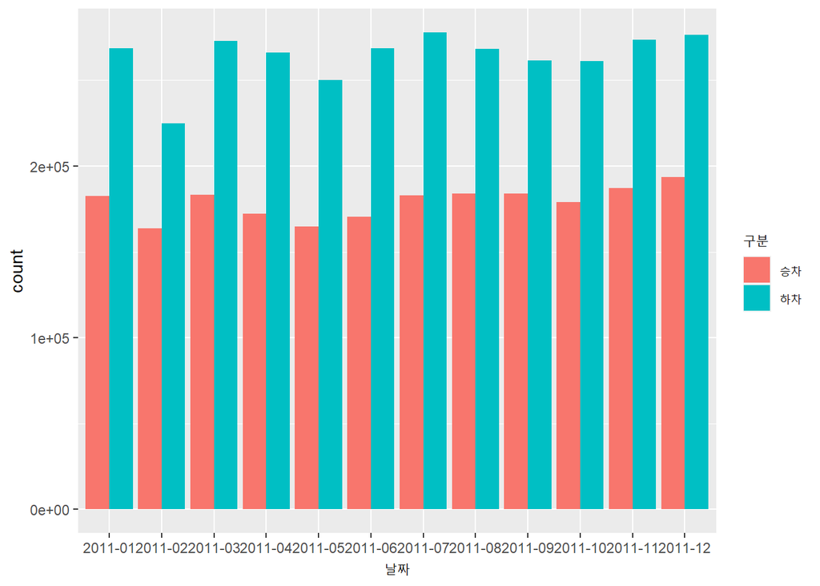

```r
ggplot(data = subwaydata_get_on_and_off_a, aes(x = 날짜, y = count, fill = 구분))+geom_col(position = "dodge")
```

```r
subwaydata_new <- subwaydata %>% filter(역명 == "압구정(326)" & 구분 == "승차")
```

#### filter를 이용해서 역명이 ’압구정역’이고 구분이 ’승차’인 데이터를 출력한다. subwaydate_new 에 데이터 저장

```r
head(subwaydata_new)
```

```
##      날짜 역번호        역명 구분 h05.06 h06.07 h07.08 h08.09 h09.10 h10.11
## 1 2011-01    326 압구정(326) 승차    831   2013   1479   6491   4064   3815
## 2 2011-01    326 압구정(326) 승차    752   1912   1441   7533   5120   4352
## 3 2011-01    326 압구정(326) 승차    786   2395   7862    511     37    205
## 4 2011-01    326 압구정(326) 승차    784   2421   7876    608    102    221
## 5 2011-01    326 압구정(326) 승차    797   2531   7970    618    174    224
## 6 2011-01    326 압구정(326) 승차    804   2428   7846    556     62    160
##   h11.12 h12.13 h13.14 h14.15 h15.16 h16.17 h17.18 h18.19 h19.20 h20.21 h21.22
## 1   4105   4723   5123   5030   5564   5778     53     55   8142   6154   6329
## 2   4183    252    364    332    399    780    763    675    616   1390    574
## 3    539    884   1360   1898   2115   2426   3242   7316   6060   3951   2891
## 4    646    885   1499   1748   2397   2533   3674   7342   6224   3993   3177
## 5    702    878   1509   1920   2381   2530   3614   7702   6073   4037   2894
## 6    598    792   1357   1733   2301   2505   3489   7368   5836   3763   3239
##   h22.23 h23.24 h24.
## 1   6298   2690    2
## 2    153   2740 1050
## 3   2247   3928  725
## 4   2721     34  735
## 5   2486    107  752
## 6   2576    138  740
```

```r
subwaydata_new1 <- dcast(subwaydata_new, 날짜~"h5", value.var = "h05.06", sum)
subwaydata_new2 <- dcast(subwaydata_new, 날짜~"h7", value.var = "h06.07", sum)
subwaydata_new3 <- dcast(subwaydata_new, 날짜~"h8", value.var = "h07.08", sum)
subwaydata_new4 <- dcast(subwaydata_new, 날짜~"h9", value.var = "h08.09", sum)
subwaydata_new5 <- dcast(subwaydata_new, 날짜~"h10", value.var = "h09.10", sum)
subwaydata_new6 <- dcast(subwaydata_new, 날짜~"h11", value.var = "h10.11", sum)
subwaydata_new7 <- dcast(subwaydata_new, 날짜~"h12", value.var = "h11.12", sum)
subwaydata_new8 <- dcast(subwaydata_new, 날짜~"h13", value.var = "h12.13", sum)
subwaydata_new9 <- dcast(subwaydata_new, 날짜~"h14", value.var = "h13.14", sum)
subwaydata_new10 <- dcast(subwaydata_new, 날짜~"h15", value.var = "h14.15", sum)
subwaydata_new11 <- dcast(subwaydata_new, 날짜~"h16", value.var = "h15.16", sum)
subwaydata_new12 <- dcast(subwaydata_new, 날짜~"h17", value.var = "h16.17", sum)
subwaydata_new13 <- dcast(subwaydata_new, 날짜~"h18", value.var = "h17.18", sum)
subwaydata_new14 <- dcast(subwaydata_new, 날짜~"h19", value.var = "h18.19", sum)
subwaydata_new15 <- dcast(subwaydata_new, 날짜~"h20", value.var = "h19.20", sum)
subwaydata_new16 <- dcast(subwaydata_new, 날짜~"h21", value.var = "h20.21", sum)
subwaydata_new17 <- dcast(subwaydata_new, 날짜~"h22", value.var = "h21.22", sum)
subwaydata_new18 <- dcast(subwaydata_new, 날짜~"h23", value.var = "h22.23", sum)
subwaydata_new19 <- dcast(subwaydata_new, 날짜~"h24", value.var = "h23.24", sum)
subwaydata_new20 <- dcast(subwaydata_new, 날짜~"h24-.", value.var = "h24.", sum)
```

#### 함수 dcast()를 이용해서 각 시간별 월 단위 구분(승차) 의 값 을 추출한다.

```r
subwaydata_get_on <- merge(subwaydata_new1, subwaydata_new2, by = '날짜')
subwaydata_get_on <- merge(subwaydata_get_on, subwaydata_new3, by = '날짜')
subwaydata_get_on <- merge(subwaydata_get_on, subwaydata_new4, by = '날짜')
subwaydata_get_on <- merge(subwaydata_get_on, subwaydata_new5, by = '날짜')
subwaydata_get_on <- merge(subwaydata_get_on, subwaydata_new6, by = '날짜')
subwaydata_get_on <- merge(subwaydata_get_on, subwaydata_new7, by = '날짜')
subwaydata_get_on <- merge(subwaydata_get_on, subwaydata_new8, by = '날짜')
subwaydata_get_on <- merge(subwaydata_get_on, subwaydata_new9, by = '날짜')
subwaydata_get_on <- merge(subwaydata_get_on, subwaydata_new10, by = '날짜')
subwaydata_get_on <- merge(subwaydata_get_on, subwaydata_new11, by = '날짜')
subwaydata_get_on <- merge(subwaydata_get_on, subwaydata_new12, by = '날짜')
subwaydata_get_on <- merge(subwaydata_get_on, subwaydata_new13, by = '날짜')
subwaydata_get_on <- merge(subwaydata_get_on, subwaydata_new14, by = '날짜')
subwaydata_get_on <- merge(subwaydata_get_on, subwaydata_new15, by = '날짜')
subwaydata_get_on <- merge(subwaydata_get_on, subwaydata_new16, by = '날짜')
subwaydata_get_on <- merge(subwaydata_get_on, subwaydata_new17, by = '날짜')
subwaydata_get_on <- merge(subwaydata_get_on, subwaydata_new18, by = '날짜')
subwaydata_get_on <- merge(subwaydata_get_on, subwaydata_new19, by = '날짜')
subwaydata_get_on <- merge(subwaydata_get_on, subwaydata_new20, by = '날짜')
```

#### merge() 함수를 이용해서 각 데이터를 날짜 기준으로 가로로 데이터를 합친다.

```r
head(subwaydata_get_on)
```

```
##      날짜    h5    h7     h8     h9   h10   h11   h12   h13   h14   h15   h16
## 1 2011-01 24572 70424 182445  90840 78999 30985 42555 32507 46213 56672 71425
## 2 2011-02 24471 61861 161664  89958 81816 36923 43014 36228 49259 57301 65505
## 3 2011-03 24489 74207  32301  99064 67025 29129 39634 26324 38991 49919 62854
## 4 2011-04 23737 72221  45213 103548 69614 25175 34538 25745 36071 45908 56875
## 5 2011-05 25234 73809  64304 128272 73121 38791 46964 29411 36911 44913 55649
## 6 2011-06 24898 73615  81850 103045 66273 27808 37361 28890 39883 45366 58045
##     h17   h18    h19    h20    h21   h22   h23   h24 h24-.
## 1 78945 94692 181362 150951 108934 84052 69376 46765 18576
## 2 71076 89212 163885 134709  90143 74526 65751 43677 18781
## 3 70701 90777 183282 147556 101539 78549 67503 40639 17452
## 4 66764 84457 172441 136532  95053 71079 58014 39317 18261
## 5 64197 82044 164713 133824  94337 70449 57491 43546 16398
## 6 67173 86808 170370 137652  96405 71028 60983 35208 19163
```

#### 데이터 확인

```r
subwaydata_get_on_a <- gather(subwaydata_get_on, hour, count, -날짜)
```

#### gather()함수로 wide에서 long 형식으로 전환

```r
subwaydata_get_on_a$날짜 <- factor(subwaydata_get_on_a$날짜, level=c('2011-01', '2011-02', '2011-03', '2011-04','2011-05','2011-06','2011-07','2011-08','2011-09','2011-10','2011-11','2011-12'), ordered=TRUE)
```

#### 레벨을 조정해야 한다. 그래프 그릴때 순서적으로 보여진다.

#### ordered=TRUE 옵션을 사용한다.

```r
subwaydata_get_on_a$hour <- factor(subwaydata_get_on_a$hour, level=c('h5', 'h7', 'h8', 'h9','h10','h11','h12','h13','h14','h15','h16','h17','h18','h19','h20','h21','h22','h23','h24','h24-.'), ordered=TRUE)
```

#### 레벨을 조정해야 한다. 그래프 그릴때 순서적으로 보여진다.

#### ordered=TRUE 옵션을 사용한다.

```r
head(subwaydata_get_on_a)
```

```
##      날짜 hour count
## 1 2011-01   h5 24572
## 2 2011-02   h5 24471
## 3 2011-03   h5 24489
## 4 2011-04   h5 23737
## 5 2011-05   h5 25234
## 6 2011-06   h5 24898
```

#### 데이터 확인

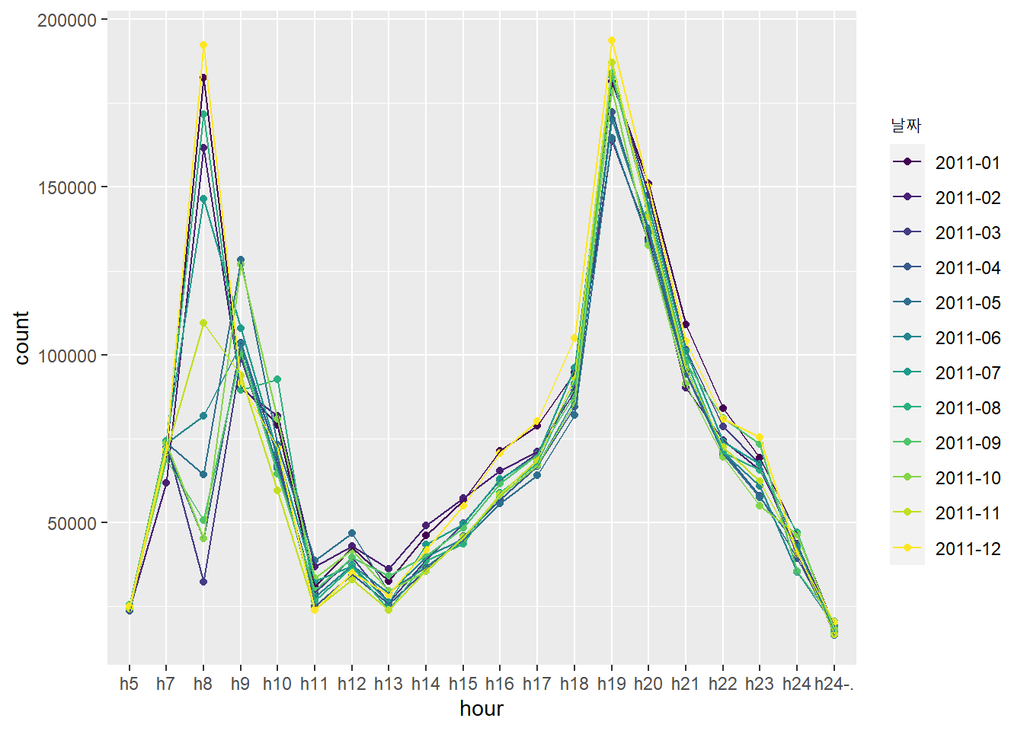

```r
ggplot(data = subwaydata_get_on_a, aes(x= hour, y= count, colour =날짜))+geom_point()+geom_line(aes(group=날짜))
```

### 2011년도 자료 압구정역 시간별 기간별 승차 그래프 시각화

```r
subwaydata_new <- subwaydata %>% filter(역명 == "압구정(326)" & 구분 == "하차")
```

#### filter를 이용해서 역명이 ’압구정역’이고 구분이 ’하차’인 데이터를 출력한다. subwaydate_new 에 데이터 저장

```r
head(subwaydata_new)
```

```
##      날짜 역번호        역명 구분 h05.06 h06.07 h07.08 h08.09 h09.10 h10.11
## 1 2011-01    326 압구정(326) 하차    933   2361   3702   9747   8025   4652
## 2 2011-01    326 압구정(326) 하차    955   2424   4740    128   2199    780
## 3 2011-01    326 압구정(326) 하차   1762    234   2817  11408   7780   2928
## 4 2011-01    326 압구정(326) 하차   1373   2950   2035  11587   7737   2786
## 5 2011-01    326 압구정(326) 하차   1551   3012   1974  11401   7781   2996
## 6 2011-01    326 압구정(326) 하차   1407   2944   1825  10909   7815   2843
##   h11.12 h12.13 h13.14 h14.15 h15.16 h16.17 h17.18 h18.19 h19.20 h20.21 h21.22
## 1     56   4662     49   5292     48     29    175     82   7677   4999   4445
## 2    619    404    710    579    675    661    566    313     19   5899   5265
## 3   2253   1546   2297   2325   1903   1813   2018   4182   2922    269   6157
## 4   2520   1653   2385   2575   2033   1967   2433   4818   3343    261   6152
## 5   2383   1695   2643   2393   2037   1952   2469   4871   3108    412   6263
## 6   2318   1738   1970   2468   1796   1735   2302   4807   3198    305   6257
##   h22.23 h23.24 h24.
## 1   3473   2107 1537
## 2   4394   2105 1814
## 3   5630   2762  728
## 4   6076   2785  764
## 5   5942   2783  733
## 6   5976   3178  790
```

#### 데이터 확인

```r
subwaydata_new1 <- dcast(subwaydata_new, 날짜~"h05.06", value.var = "h05.06", sum)
subwaydata_new2 <- dcast(subwaydata_new, 날짜~"h06.07", value.var = "h06.07", sum)
subwaydata_new3 <- dcast(subwaydata_new, 날짜~"h07.08", value.var = "h07.08", sum)
subwaydata_new4 <- dcast(subwaydata_new, 날짜~"h08.09", value.var = "h08.09", sum)
subwaydata_new5 <- dcast(subwaydata_new, 날짜~"h09.10", value.var = "h09.10", sum)
subwaydata_new6 <- dcast(subwaydata_new, 날짜~"h10.11", value.var = "h10.11", sum)
subwaydata_new7 <- dcast(subwaydata_new, 날짜~"h11.12", value.var = "h11.12", sum)
subwaydata_new8 <- dcast(subwaydata_new, 날짜~"h12.13", value.var = "h12.13", sum)
subwaydata_new9 <- dcast(subwaydata_new, 날짜~"h13.14", value.var = "h13.14", sum)
subwaydata_new10 <- dcast(subwaydata_new, 날짜~"h14.15", value.var = "h14.15", sum)
subwaydata_new11 <- dcast(subwaydata_new, 날짜~"h15.16", value.var = "h15.16", sum)
subwaydata_new12 <- dcast(subwaydata_new, 날짜~"h16.17", value.var = "h16.17", sum)
subwaydata_new13 <- dcast(subwaydata_new, 날짜~"h17.18", value.var = "h17.18", sum)
subwaydata_new14 <- dcast(subwaydata_new, 날짜~"h18.19", value.var = "h18.19", sum)
subwaydata_new15 <- dcast(subwaydata_new, 날짜~"h19.20", value.var = "h19.20", sum)
subwaydata_new16 <- dcast(subwaydata_new, 날짜~"h20.21", value.var = "h20.21", sum)
subwaydata_new17 <- dcast(subwaydata_new, 날짜~"h21.22", value.var = "h21.22", sum)
subwaydata_new18 <- dcast(subwaydata_new, 날짜~"h22.23", value.var = "h22.23", sum)
subwaydata_new19 <- dcast(subwaydata_new, 날짜~"h23.24", value.var = "h23.24", sum)
subwaydata_new20 <- dcast(subwaydata_new, 날짜~"h24.", value.var = "h24.", sum)
```

#### 함수 dcast()를 이용해서 각 시간별 월 단위 구분(하차) 의 값 을 추출한다.

```r
subwaydata_get_off <- merge(subwaydata_new1, subwaydata_new2, by = '날짜')
subwaydata_get_off <- merge(subwaydata_get_off, subwaydata_new3, by = '날짜')
subwaydata_get_off <- merge(subwaydata_get_off, subwaydata_new4, by = '날짜')
subwaydata_get_off <- merge(subwaydata_get_off, subwaydata_new5, by = '날짜')
subwaydata_get_off <- merge(subwaydata_get_off, subwaydata_new6, by = '날짜')
subwaydata_get_off <- merge(subwaydata_get_off, subwaydata_new7, by = '날짜')
subwaydata_get_off <- merge(subwaydata_get_off, subwaydata_new8, by = '날짜')
subwaydata_get_off <- merge(subwaydata_get_off, subwaydata_new9, by = '날짜')
subwaydata_get_off <- merge(subwaydata_get_off, subwaydata_new10, by = '날짜')
subwaydata_get_off <- merge(subwaydata_get_off, subwaydata_new11, by = '날짜')
subwaydata_get_off <- merge(subwaydata_get_off, subwaydata_new12, by = '날짜')
subwaydata_get_off <- merge(subwaydata_get_off, subwaydata_new13, by = '날짜')
subwaydata_get_off <- merge(subwaydata_get_off, subwaydata_new14, by = '날짜')
subwaydata_get_off <- merge(subwaydata_get_off, subwaydata_new15, by = '날짜')
subwaydata_get_off <- merge(subwaydata_get_off, subwaydata_new16, by = '날짜')
subwaydata_get_off <- merge(subwaydata_get_off, subwaydata_new17, by = '날짜')
subwaydata_get_off <- merge(subwaydata_get_off, subwaydata_new18, by = '날짜')
subwaydata_get_off <- merge(subwaydata_get_off, subwaydata_new19, by = '날짜')
subwaydata_get_off <- merge(subwaydata_get_off, subwaydata_new20, by = '날짜')
```

#### merge() 함수를 이용해서 각 데이터를 날짜 기준으로 가로로 데이터를 합친다.

```r
head(subwaydata_get_off)
```

```
##      날짜 h05.06 h06.07 h07.08 h08.09 h09.10 h10.11 h11.12 h12.13 h13.14 h14.15
## 1 2011-01  42856  83084  88011 268525 206258  86000  67103  56748  69422  72898
## 2 2011-02  38066  67696  79526 224930 172715  73480  68138  56326  71308  72141
## 3 2011-03  45480  83122  98506 272858 202293  78482  64717  46116  57941  59105
## 4 2011-04  42947  83440  90007 266108 194728  75594  59665  43860  53636  55025
## 5 2011-05  42399  83084 101156 250208 190485  72830  60397  43800  54111  54250
## 6 2011-06  43737  80939  87930 268568 194649  73437  61330  45124  56691  53633
##   h15.16 h16.17 h17.18 h18.19 h19.20 h20.21 h21.22 h22.23 h23.24  h24.
## 1  56716  54240  62966 118229  87954  47917 135577 168995  87371 29370
## 2  66105  67397  65157 124458  93265  46832 123763 147857  79827 26593
## 3  52310  51638  67293 126517  79497  41328 141005 168691  95597 27946
## 4  48110  46392  58617 115250  69741  40258 110281 162125  93287 27189
## 5  48926  47246  59842 109806  74397  52785  97615 158215  95095 28039
## 6  48038  46596  59104 111630  82696  39610 123833 162998  92215 26069
```

#### 데이터 확인

```r
subwaydata_get_off_a <- gather(subwaydata_get_off, hour, count, -날짜)
```

#### gather()함수로 wide에서 long 형식으로 전환

```r
subwaydata_get_off_a$날짜 <- factor(subwaydata_get_off_a$날짜, level=c('2011-01', '2011-02', '2011-03', '2011-04','2011-05','2011-06','2011-07','2011-08','2011-09','2011-10','2011-11','2011-12'), ordered=TRUE)
```

#### 레벨을 조정해야 한다. 그래프 그릴때 순서적으로 보여진다.

#### ordered=TRUE 옵션을 사용한다.

```r
subwaydata_get_off_a$hour <- factor(subwaydata_get_off_a$hour, level=c('h05.06', 'h06.07', 'h07.08', 'h08.09','h09.10','h10.11','h11.12','h12.13','h13.14','h14.15','h15.16','h16.17','h17.18','h18.19','h19.20','h20.21','h21.22','h22.23','h23.24','h24.'), ordered=TRUE)
```

#### 레벨을 조정해야 한다. 그래프 그릴때 순서적으로 보여진다.

### ordered=TRUE 옵션을 사용한다.

```r
head(subwaydata_get_off_a)
```

```
##      날짜   hour count
## 1 2011-01 h05.06 42856
## 2 2011-02 h05.06 38066
## 3 2011-03 h05.06 45480
## 4 2011-04 h05.06 42947
## 5 2011-05 h05.06 42399
## 6 2011-06 h05.06 43737
```

#### 데이터 확인

```r
subwaydata_get_on_a
```

[output not shown]

[output cut: 226 more lines]

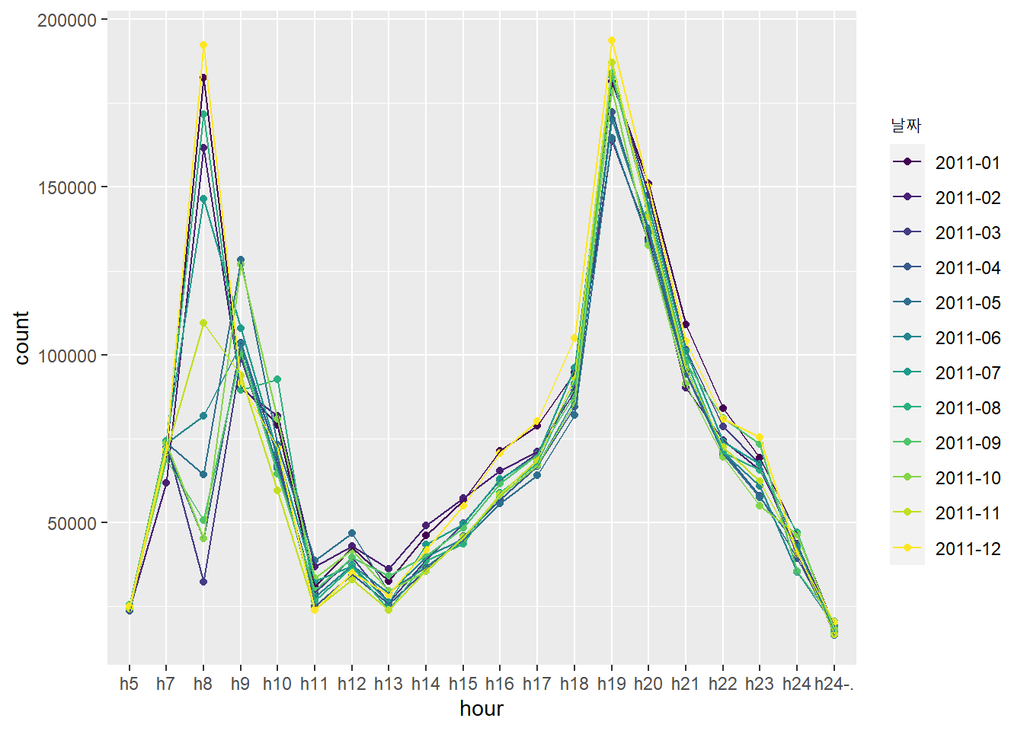

```r
ggplot(data = subwaydata_get_on_a, aes(x= hour, y= count, colour =날짜), height = 100)+geom_point()+geom_line(aes(group=날짜))
```

```r
help(ggplot)
```

```
## starting httpd help server ... done
```